# PART-A

1. Please refer the table below to answer below questions:

| Planned to purchase Product A | Actually placed order for Product A - Yes | Actually placed order for Product A - No | Total |
| --- | --- | --- | --- |
| Yes | 400 | 100 | 500 |
| No | 200 | 1300 | 1500 |
| Total | 600 | 1400 | 2000 |

```python
#1.A. Refer above table and find the joint probability of the people who planned to purchase and actually placed an order.

# Need to find P ( A and B) where P(A)= Probability of people placed an order and p(B)= Probability of people planned to purchase a order

Prob_of_AandB=400/2000
print("Joint Probability of people who planned to purchase and Actually placed an order =",Prob_of_AandB)
```

```
Joint Probability of people who planned to purchase and Actually placed an order = 0.2
```

```python
#1.B. Refer to the above table and find the joint probability of the people who planned to purchase and actually placed an order, given that people planned to purchase.

#conditional Probability = P(A and B) / p(B)  ; where P(A)= Probability of people placed an order and p(B)= Probability of people planned to purchase a order

Prob_of_AandB=400/2000
print("P(A and B) =",Prob_of_AandB)
Prob_of_B=500/2000
print("P(B) =",Prob_of_B)

print("P(Joint probability of the people who planned to purchase and actually placed an order, given that people planned to purchase) =", Prob_of_AandB/Prob_of_B)
```

```
P(A and B) = 0.2
P(B) = 0.25
P(Joint probability of the people who planned to purchase and actually placed an order, given that people planned to purchase) = 0.8
```

2.An electrical manufacturing company conducts quality checks at specified periods on the products it manufactures. Historically, the failure rate for the manufactured item is 5%. Suppose a random sample of 10 manufactured items is selected. Answer the following questions.

```python
#Data given = N and Failure Rate . so Lets choose Binomial distribution.
import numpy as np
import scipy.stats as stats
import matplotlib.pyplot as plt
n=10
p=0.05
q=1-p
k = np.arange(0,n+1)
Binomial_Distribution= stats.binom.pmf(k,n,p)
Binomial_Distribution_cdf= stats.binom.cdf(k,n,p)

#2.A. Probability that none of the items are defective?
print("Probability that none of the items are defective P(x=0)=",Binomial_Distribution[0].round(4))
```

```
Probability that none of the items are defective P(x=0)= 0.5987
```

```python
#2.B. Probability that exactly one of the items is defective?
print("Probability of exactly one of the items is defective P(x=1)=",Binomial_Distribution[1].round(4))
```

```
Probability of exactly one of the items is defective P(x=1)= 0.3151
```

```python
#2.C. Probability that two or fewer of the items are defective?
print("Using PMF- Probability that two or fewer of the items are defective p(x<=2)=",(Binomial_Distribution[0]+Binomial_Distribution[1]+Binomial_Distribution[2]).round(4))
print("Using CDF- Probability that two or fewer of the items are defective p(x<=2)=",(Binomial_Distribution_cdf[2]).round(4))
```

```
Using PMF- Probability that two or fewer of the items are defective p(x<=2)= 0.9885
Using CDF- Probability that two or fewer of the items are defective p(x<=2)= 0.9885
```

```python
#2.D. Probability that three or more of the items are defective ?
prob_fewerthan3_defective=Binomial_Distribution[0]+Binomial_Distribution[1]+Binomial_Distribution[2] #p(x<3)

print("Using PMF -Probability that three or more of the items are defective p(x>=3)=",(1-prob_fewerthan3_defective).round(4)) #p(x>=3)=1-p(x<3)
print("Using CDF -Probability that three or more of the items are defective p(x>=3)=",(1-Binomial_Distribution_cdf[2]).round(4))
```

```
Using PMF -Probability that three or more of the items are defective p(x>=3)= 0.0115
Using CDF -Probability that three or more of the items are defective p(x>=3)= 0.0115
```

3.A car salesman sells on an average 3 cars per week.

```python
# Avg rate is given , hence choose poisson distribution
# lamba = 3 ( Avg number of succcess per week) , k =21 (Total number of success in a week is 7*3)
rate=3
k=np.arange(0,21)
Poisson_Distribution = stats.poisson.pmf(k,rate)
Poisson_Distribution_CDF = stats.poisson.cdf(k,rate)
#3.A. What is Probability that in a given week he will sell some cars?
# he will sell some cars in the sense atleast one car which is greater than zero

print("Using - PMF Probability that in a given week he will sell some cars p(x>0)=",(1-Poisson_Distribution[0]).round(4)) #p(x>0)=1-p(x=0)
print("Using - CDF Probability that in a given week he will sell some cars p(x>0)=",(1-Poisson_Distribution_CDF[0]).round(4))
```

```
Using - PMF Probability that in a given week he will sell some cars p(x>0)= 0.9502
Using - CDF Probability that in a given week he will sell some cars p(x>0)= 0.9502
```

```python
#3.B. What is Probability that in a given week he will sell 2 or more but less than 5 cars?
print("Using - PMF Probability that in a given week he will sell 2 or more but less than 5 cars p(x>=2 and x<5)=",(Poisson_Distribution[2]+Poisson_Distribution[3]+Poisson_Distribution[4]).round(4)) #p(2,3,4)
print("Using - CDF Probability that in a given week he will sell 2 or more but less than 5 cars p(x>=2 and x<5)=",(Poisson_Distribution_CDF[4]-Poisson_Distribution_CDF[1]).round(4))
```

```
Using - PMF Probability that in a given week he will sell 2 or more but less than 5 cars p(x>=2 and x<5)= 0.6161
Using - CDF Probability that in a given week he will sell 2 or more but less than 5 cars p(x>=2 and x<5)= 0.6161
```

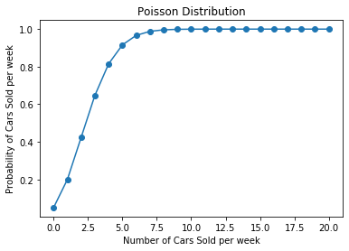

```python
#3.C. Plot the poisson distribution function for cumulative probability of cars sold per-week vs number of cars sold per week.

plt.plot(k,Poisson_Distribution_CDF, 'o-')
plt.title('Poisson Distribution')
plt.xlabel('Number of Cars Sold per week')
plt.ylabel('Probability of Cars Sold per week')
plt.show()
```

4.Accuracy in understanding orders for a speech based bot at a restaurant is important for the Company X which has designed, marketed and launched the product for a contactless delivery due to the COVID-19 pandemic. Recognition accuracy that measures the percentage of orders that are taken correctly is 86.8%. Suppose that you place an order with the bot and two friends of yours independently place orders with the same bot. Answer the following questions.

```python
#4.A. What is the probability that all three orders will be recognised correctly?

n=3
p=0.868
k = np.arange(0,n+1)
Binomial_Distribution= stats.binom.pmf(k,n,p)
Binomial_Distribution_CDF=stats.binom.cdf(k,n,p)


print("Using PMF - P(All 3 orders recognized correctly)=",(Binomial_Distribution[1]+Binomial_Distribution[2]+Binomial_Distribution[3]).round(4))
print("Using CDF - P(All 3 orders recognized correctly)=",(Binomial_Distribution_CDF[3]-Binomial_Distribution_CDF[0]).round(4))
```

[output not shown]

```python
#4.B. What is the probability that none of the three orders will be recognised correctly?
print("P(None of the oreder Recognized correctly)=",(Binomial_Distribution[0]).round(4))
```

```
P(None of the oreder Recognized correctly)= 0.0023
```

```python
#4.C. What is the probability that at least two of the three orders will be recognised correctly?
print("Using PMF - P(Atleast Two order Recognized correctly)=",(Binomial_Distribution[2]+Binomial_Distribution[3]).round(4))
print("Using CDF - P(Atleast Two order Recognized correctly)=",(Binomial_Distribution_CDF[3]-Binomial_Distribution_CDF[1]).round(4))
```

```
Using PMF - P(Atleast Two order Recognized correctly)= 0.9523
Using CDF - P(Atleast Two order Recognized correctly)= 0.9523
```

5.Explain 1 real life industry scenario (other than the ones mentioned above) where you can use the concepts learnt in this module of Applied Statistics to get data driven business solution.

Applied Statistics can be used in my project(Automation) as mentioned below

Descriptive Statistics:

1. Identify the Bot accuracy.
2. How Accuracy affects by retraining the Bot with latest data. ( Improved or Not)
3. Identify under what circumstace bot failure occurs and try to rectify it
4. Does RPA (Robotic Process Automation )based solution performs better than Code based approach.

Inferential Statistics:

1. How much Efforts can be saved by increasing no.of automation workflow.
2. finding the probability of the achieving N% of automation in this year.

And this data preparation , i used it to clean the ticket dumps from ticketing tool for classifier bot. Understood the distribution of tickets across Assignment group.

Problem Statement : The Classifier bot predicted the assignment group of the ticket from description with 75 % accuracy and After production movement ,1000 tickets came for the quarter what is the probability that Classifier will predict more than 900 tickets assignment group correctly.

# PART- B

PROJECT OBJECTIVE: Company’s management wants to invest on proposals on managing some of the best teams in the league. The analytics department has been assigned with a task of creating a report on the performance shown by the teams. Some of the older teams are already in contract with competitors. Hence Company X wants to understand which teams they can approach which will be a deal win for them.

1. Read the data set, clean the data and prepare final dataset to be used for analysis.

```python
import numpy as np
import pandas as pd
import seaborn as sns;
BasketBallData=pd.read_csv("C:\\Users\\AN953317\\Downloads\\Basketball.csv")
BasketBallData
```

|  | Team | Tournament | Score | PlayedGames | WonGames | DrawnGames | LostGames | BasketScored | BasketGiven | TournamentChampion | Runner-up | TeamLaunch | HighestPositionHeld |
| --- | --- | --- | --- | --- | --- | --- | --- | --- | --- | --- | --- | --- | --- |
| 0 | Team 1 | 86 | 4385 | 2762 | 1647 | 552 | 563 | 5947 | 3140 | 33 | 23 | 1929 | 1 |
| 1 | Team 2 | 86 | 4262 | 2762 | 1581 | 573 | 608 | 5900 | 3114 | 25 | 25 | 1929 | 1 |
| 2 | Team 3 | 80 | 3442 | 2614 | 1241 | 598 | 775 | 4534 | 3309 | 10 | 8 | 1929 | 1 |
| 3 | Team 4 | 82 | 3386 | 2664 | 1187 | 616 | 861 | 4398 | 3469 | 6 | 6 | 1931to32 | 1 |
| 4 | Team 5 | 86 | 3368 | 2762 | 1209 | 633 | 920 | 4631 | 3700 | 8 | 7 | 1929 | 1 |
| 5 | Team 6 | 73 | 2819 | 2408 | 990 | 531 | 887 | 3680 | 3373 | 1 | 4 | 1934-35 | 1 |
| 6 | Team 7 | 82 | 2792 | 2626 | 948 | 608 | 1070 | 3609 | 3889 | - | - | 1929 | 3 |
| 7 | Team 8 | 70 | 2573 | 2302 | 864 | 577 | 861 | 3228 | 3230 | 2 | 3 | 1929 | 1 |
| 8 | Team 9 | 58 | 2109 | 1986 | 698 | 522 | 766 | 2683 | 2847 | - | 1 | 1939-40 | 2 |
| 9 | Team 10 | 51 | 1884 | 1728 | 606 | 440 | 682 | 2159 | 2492 | 1 | - | 1932-33 | 1 |
| 10 | Team 11 | 45 | 1814 | 1530 | 563 | 392 | 575 | 2052 | 2188 | 1 | 5 | 1941to42 | 1 |
| 11 | Team 12 | 51 | 1789 | 1698 | 586 | 389 | 723 | 2278 | 2624 | - | - | 1939-40 | 4 |
| 12 | Team 13 | 42 | 1471 | 1466 | 463 | 384 | 619 | 1767 | 2180 | - | - | 1948-49 | 4 |
| 13 | Team 14 | 44 | 1416 | 1428 | 453 | 336 | 639 | 1843 | 2368 | - | 1 | 1929 | 2 |
| 14 | Team 15 | 43 | 1389 | 1458 | 471 | 358 | 629 | 1753 | 2152 | - | 1 | 1944_45 | 2 |
| 15 | Team 16 | 37 | 1351 | 1318 | 426 | 327 | 565 | 1500 | 1834 | - | - | 1935-36 | 4 |
| 16 | Team 17 | 36 | 1314 | 1255 | 390 | 330 | 535 | 1421 | 1763 | - | - | 1949_50 | 4 |
| 17 | Team 18 | 38 | 1174 | 1192 | 408 | 292 | 492 | 1642 | 1951 | - | - | 1933to34 | 3 |
| 18 | Team 19 | 27 | 1148 | 988 | 333 | 256 | 399 | 1182 | 1371 | - | - | 1960-61 | 3 |
| 19 | Team 20 | 33 | 1020 | 1096 | 367 | 242 | 487 | 1347 | 1746 | - | 1 | 1951-52 | 2 |
| 20 | Team 21 | 17 | 970 | 646 | 266 | 172 | 208 | 892 | 789 | - | 1 | 1998-99 | 2 |
| 21 | Team 22 | 23 | 667 | 742 | 218 | 175 | 349 | 819 | 1157 | - | - | 1941-42 | 6 |
| 22 | Team 23 | 17 | 662 | 652 | 189 | 148 | 305 | 760 | 1088 | - | - | 1977-78 | 8 |
| 23 | Team 24 | 21 | 606 | 678 | 203 | 180 | 295 | 750 | 1022 | - | - | 1959-60 | 5 |
| 24 | Team 25 | 12 | 553 | 456 | 147 | 112 | 197 | 520 | 633 | - | - | 2004to05 | 6 |
| 25 | Team 26 | 20 | 538 | 628 | 184 | 149 | 295 | 716 | 1050 | - | - | 1935-36 | 5 |
| 26 | Team 27 | 13 | 510 | 494 | 155 | 128 | 211 | 619 | 744 | - | - | 1961-62 | 5 |
| 27 | Team 28 | 18 | 445 | 586 | 145 | 143 | 298 | 607 | 992 | - | - | 1940-41 | 11 |
| 28 | Team 29 | 12 | 421 | 380 | 125 | 81 | 174 | 458 | 623 | - | - | 1930-31 | 6 |
| 29 | Team 30 | 11 | 416 | 402 | 113 | 95 | 194 | 430 | 632 | - | - | 1963-64 | 6 |
| ... | ... | ... | ... | ... | ... | ... | ... | ... | ... | ... | ... | ... | ... |
| 31 | Team 32 | 14 | 353 | 426 | 129 | 95 | 202 | 492 | 720 | - | - | 1943-44 | 4 |
| 32 | Team 33 | 12 | 343 | 448 | 104 | 127 | 217 | 393 | 662 | - | - | 1977-78 | 12 |
| 33 | Team 34 | 9 | 293 | 346 | 96 | 92 | 158 | 291 | 489 | - | - | 1987-88 | 7 |
| 34 | Team 35 | 11 | 285 | 334 | 103 | 79 | 152 | 419 | 588 | - | - | 1941-42 | 4 |
| 35 | Team 36 | 7 | 277 | 270 | 76 | 76 | 118 | 320 | 410 | - | - | 1991_92 | 7 |
| 36 | Team 37 | 6 | 242 | 228 | 62 | 56 | 110 | 244 | 366 | - | - | 2007-08 | 8 |
| 37 | Team 38 | 9 | 230 | 282 | 82 | 63 | 137 | 285 | 430 | - | - | 1962-63 | 5 |
| 38 | Team 39 | 4 | 190 | 160 | 52 | 45 | 63 | 199 | 241 | - | - | 1994-95 | 10 |
| 39 | Team 40 | 5 | 188 | 186 | 50 | 46 | 90 | 202 | 296 | - | - | 1978-79 | 8 |
| 40 | Team 41 | 6 | 168 | 204 | 59 | 50 | 95 | 216 | 310 | - | - | 1971-72 | 12 |
| 41 | Team 42 | 6 | 150 | 180 | 53 | 44 | 83 | 165 | 221 | - | - | 1963-64 | 7 |
| 42 | Team 43 | 4 | 148 | 152 | 37 | 37 | 78 | 155 | 253 | - | - | 1999to00 | 17 |
| 43 | Team 44 | 3 | 132 | 114 | 35 | 27 | 52 | 139 | 167 | - | - | 2014-15 | 10 |
| 44 | Team 45 | 7 | 107 | 130 | 43 | 21 | 66 | 227 | 308 | - | - | 1929 | 3 |
| 45 | Team 46 | 3 | 96 | 114 | 26 | 44 | 44 | 101 | 139 | - | - | 1990-91 | 9 |
| 46 | Team 47 | 4 | 91 | 116 | 34 | 16 | 66 | 181 | 295 | - | - | 1947-48 | 7 |
| 47 | Team 48 | 2 | 83 | 80 | 20 | 23 | 37 | 62 | 117 | - | - | 1996-97 | 17 |
| 48 | Team 49 | 2 | 81 | 80 | 19 | 24 | 37 | 70 | 115 | - | - | 1995-96 | 19 |
| 49 | Team 50 | 4 | 76 | 108 | 30 | 16 | 62 | 145 | 252 | - | - | 1945-46 | 10 |
| 50 | Team 51 | 3 | 71 | 90 | 29 | 13 | 48 | 121 | 183 | - | - | 1953-54 | 14 |
| 51 | Team 52 | 4 | 56 | 72 | 21 | 14 | 37 | 153 | 184 | - | - | 1929 | 6 |
| 52 | Team 53 | 2 | 52 | 68 | 17 | 18 | 33 | 71 | 116 | - | - | 1979-80 | 10 |
| 53 | Team 54 | 3 | 42 | 54 | 18 | 6 | 30 | 97 | 131 | - | - | 1929 | 8 |
| 54 | Team 55 | 2 | 40 | 68 | 13 | 14 | 41 | 70 | 182 | - | - | 1950-51 | 16 |
| 55 | Team 56 | 1 | 35 | 38 | 8 | 11 | 19 | 36 | 55 | - | - | 2016_17 | 17 |
| 56 | Team 57 | 1 | 34 | 38 | 8 | 10 | 20 | 38 | 66 | - | - | 2009-10 | 20 |
| 57 | Team 58 | 1 | 22 | 30 | 7 | 8 | 15 | 37 | 57 | - | - | 1956-57 | 16 |
| 58 | Team 59 | 1 | 19 | 30 | 7 | 5 | 18 | 51 | 85 | - | - | 1951~52 | 16 |
| 59 | Team 60 | 1 | 14 | 30 | 5 | 4 | 21 | 34 | 65 | - | - | 1955-56 | 15 |
| 60 | Team 61 | 1 | - | - | - | - | - | - | - | - | - | 2017~18 | 9 |

61 rows × 13 columns

```python
BasketBallData.shape
```

```
(61, 13)
```

```python
BasketBallData.head()
```

|  | Team | Tournament | Score | PlayedGames | WonGames | DrawnGames | LostGames | BasketScored | BasketGiven | TournamentChampion | Runner-up | TeamLaunch | HighestPositionHeld |
| --- | --- | --- | --- | --- | --- | --- | --- | --- | --- | --- | --- | --- | --- |
| 0 | Team 1 | 86 | 4385 | 2762 | 1647 | 552 | 563 | 5947 | 3140 | 33 | 23 | 1929 | 1 |
| 1 | Team 2 | 86 | 4262 | 2762 | 1581 | 573 | 608 | 5900 | 3114 | 25 | 25 | 1929 | 1 |
| 2 | Team 3 | 80 | 3442 | 2614 | 1241 | 598 | 775 | 4534 | 3309 | 10 | 8 | 1929 | 1 |
| 3 | Team 4 | 82 | 3386 | 2664 | 1187 | 616 | 861 | 4398 | 3469 | 6 | 6 | 1931to32 | 1 |
| 4 | Team 5 | 86 | 3368 | 2762 | 1209 | 633 | 920 | 4631 | 3700 | 8 | 7 | 1929 | 1 |

## Inference From Head

Observing Head of the data - Here TeamLaunch of Team 4 have range of years from 1931to32 which is different from other data

```python
BasketBallData.tail()
```

|  | Team | Tournament | Score | PlayedGames | WonGames | DrawnGames | LostGames | BasketScored | BasketGiven | TournamentChampion | Runner-up | TeamLaunch | HighestPositionHeld |
| --- | --- | --- | --- | --- | --- | --- | --- | --- | --- | --- | --- | --- | --- |
| 56 | Team 57 | 1 | 34 | 38 | 8 | 10 | 20 | 38 | 66 | - | - | 2009-10 | 20 |
| 57 | Team 58 | 1 | 22 | 30 | 7 | 8 | 15 | 37 | 57 | - | - | 1956-57 | 16 |
| 58 | Team 59 | 1 | 19 | 30 | 7 | 5 | 18 | 51 | 85 | - | - | 1951~52 | 16 |
| 59 | Team 60 | 1 | 14 | 30 | 5 | 4 | 21 | 34 | 65 | - | - | 1955-56 | 15 |
| 60 | Team 61 | 1 | - | - | - | - | - | - | - | - | - | 2017~18 | 9 |

## Inference From Tail

1. Tournament Champion are '-'
2. RunnerUp are '-'
3. Team launch is 2017~18,1956-57 [ Has special character in between ]

```python
#Checking the type of data and
#Other than '-' Checking for other Missing Data
BasketBallData.info()
```

```
<class 'pandas.core.frame.DataFrame'>
RangeIndex: 61 entries, 0 to 60
Data columns (total 13 columns):
Team                   61 non-null object
Tournament             61 non-null int64
Score                  61 non-null object
PlayedGames            61 non-null object
WonGames               61 non-null object
DrawnGames             61 non-null object
LostGames              61 non-null object
BasketScored           61 non-null object
BasketGiven            61 non-null object
TournamentChampion     61 non-null object
Runner-up              61 non-null object
TeamLaunch             61 non-null object
HighestPositionHeld    61 non-null int64
dtypes: int64(2), object(11)
memory usage: 6.3+ KB
```

## Inference from Info

All are numbers but the datatype is Object . need to convert to int for further processing.

```python
#ColumnWise Missing data
BasketBallData.isna().sum()
```

```
Team                   0
Tournament             0
Score                  0
PlayedGames            0
WonGames               0
DrawnGames             0
LostGames              0
BasketScored           0
BasketGiven            0
TournamentChampion     0
Runner-up              0
TeamLaunch             0
HighestPositionHeld    0
dtype: int64
```

```python
BasketBallData.describe(include='all')
```

|  | Team | Tournament | Score | PlayedGames | WonGames | DrawnGames | LostGames | BasketScored | BasketGiven | TournamentChampion | Runner-up | TeamLaunch | HighestPositionHeld |
| --- | --- | --- | --- | --- | --- | --- | --- | --- | --- | --- | --- | --- | --- |
| count | 61 | 61.000000 | 61 | 61 | 61 | 61 | 61 | 61 | 61 | 61 | 61 | 61 | 61.000000 |
| unique | 61 | NaN | 61 | 53 | 59 | 57 | 56 | 60 | 61 | 8 | 10 | 47 | NaN |
| top | Team 43 | NaN | 168 | 30 | 7 | 95 | 37 | 70 | 430 | - | - | 1929 | NaN |
| freq | 1 | NaN | 1 | 3 | 2 | 2 | 3 | 2 | 1 | 52 | 48 | 10 | NaN |
| mean | NaN | 24.000000 | NaN | NaN | NaN | NaN | NaN | NaN | NaN | NaN | NaN | NaN | 7.081967 |
| std | NaN | 26.827225 | NaN | NaN | NaN | NaN | NaN | NaN | NaN | NaN | NaN | NaN | 5.276663 |
| min | NaN | 1.000000 | NaN | NaN | NaN | NaN | NaN | NaN | NaN | NaN | NaN | NaN | 1.000000 |
| 25% | NaN | 4.000000 | NaN | NaN | NaN | NaN | NaN | NaN | NaN | NaN | NaN | NaN | 3.000000 |
| 50% | NaN | 12.000000 | NaN | NaN | NaN | NaN | NaN | NaN | NaN | NaN | NaN | NaN | 6.000000 |
| 75% | NaN | 38.000000 | NaN | NaN | NaN | NaN | NaN | NaN | NaN | NaN | NaN | NaN | 10.000000 |
| max | NaN | 86.000000 | NaN | NaN | NaN | NaN | NaN | NaN | NaN | NaN | NaN | NaN | 20.000000 |

## Inference From Missing Data

isna function gives zero count but describe says most of the column has NotANumber. Hence there must be a missing data as observed '-' from tail

```python
#check duplicates
BasketBallData.duplicated().sum()
```

```
0
```

## Inference From Duplicates

No Duplicates Available

## Action needs to be taken on below inferences:

1. Tournament Champion are '-' #Since they havent been a champion it may be marked as - . so lets change it to 0
2. RunnerUp are '-' #for the same reason as above . Lets change it to 0
3. Team launch is 2017~18,1956-57 1937to34 # Has special character in between and also its a range . for team launch lets us assume the start year alone.
4. All are numbers but the datatype is Object # need to convert to int for further processing.

```python
BasketBallDataOriginal=BasketBallData.copy(deep='True')
BasketBallData=BasketBallData.replace('-',0)  #Action 1 and Action 2
BasketBallData['TeamLaunch']=BasketBallData['TeamLaunch'].str.slice(0,4) #Action 3
series=BasketBallData.columns.drop('Team') #Action 4 - except first column [team] trying to change everything to int
BasketBallData[series]=BasketBallData[series].apply(pd.to_numeric)
BasketBallData.info()
```

```
<class 'pandas.core.frame.DataFrame'>
RangeIndex: 61 entries, 0 to 60
Data columns (total 13 columns):
Team                   61 non-null object
Tournament             61 non-null int64
Score                  61 non-null int64
PlayedGames            61 non-null int64
WonGames               61 non-null int64
DrawnGames             61 non-null int64
LostGames              61 non-null int64
BasketScored           61 non-null int64
BasketGiven            61 non-null int64
TournamentChampion     61 non-null int64
Runner-up              61 non-null int64
TeamLaunch             61 non-null int64
HighestPositionHeld    61 non-null int64
dtypes: int64(12), object(1)
memory usage: 6.3+ KB
```

```python
#Cleaned DATA is below
BasketBallData
```

|  | Team | Tournament | Score | PlayedGames | WonGames | DrawnGames | LostGames | BasketScored | BasketGiven | TournamentChampion | Runner-up | TeamLaunch | HighestPositionHeld |
| --- | --- | --- | --- | --- | --- | --- | --- | --- | --- | --- | --- | --- | --- |
| 0 | Team 1 | 86 | 4385 | 2762 | 1647 | 552 | 563 | 5947 | 3140 | 33 | 23 | 1929 | 1 |
| 1 | Team 2 | 86 | 4262 | 2762 | 1581 | 573 | 608 | 5900 | 3114 | 25 | 25 | 1929 | 1 |
| 2 | Team 3 | 80 | 3442 | 2614 | 1241 | 598 | 775 | 4534 | 3309 | 10 | 8 | 1929 | 1 |
| 3 | Team 4 | 82 | 3386 | 2664 | 1187 | 616 | 861 | 4398 | 3469 | 6 | 6 | 1931 | 1 |
| 4 | Team 5 | 86 | 3368 | 2762 | 1209 | 633 | 920 | 4631 | 3700 | 8 | 7 | 1929 | 1 |
| 5 | Team 6 | 73 | 2819 | 2408 | 990 | 531 | 887 | 3680 | 3373 | 1 | 4 | 1934 | 1 |
| 6 | Team 7 | 82 | 2792 | 2626 | 948 | 608 | 1070 | 3609 | 3889 | 0 | 0 | 1929 | 3 |
| 7 | Team 8 | 70 | 2573 | 2302 | 864 | 577 | 861 | 3228 | 3230 | 2 | 3 | 1929 | 1 |
| 8 | Team 9 | 58 | 2109 | 1986 | 698 | 522 | 766 | 2683 | 2847 | 0 | 1 | 1939 | 2 |
| 9 | Team 10 | 51 | 1884 | 1728 | 606 | 440 | 682 | 2159 | 2492 | 1 | 0 | 1932 | 1 |
| 10 | Team 11 | 45 | 1814 | 1530 | 563 | 392 | 575 | 2052 | 2188 | 1 | 5 | 1941 | 1 |
| 11 | Team 12 | 51 | 1789 | 1698 | 586 | 389 | 723 | 2278 | 2624 | 0 | 0 | 1939 | 4 |
| 12 | Team 13 | 42 | 1471 | 1466 | 463 | 384 | 619 | 1767 | 2180 | 0 | 0 | 1948 | 4 |
| 13 | Team 14 | 44 | 1416 | 1428 | 453 | 336 | 639 | 1843 | 2368 | 0 | 1 | 1929 | 2 |
| 14 | Team 15 | 43 | 1389 | 1458 | 471 | 358 | 629 | 1753 | 2152 | 0 | 1 | 1944 | 2 |
| 15 | Team 16 | 37 | 1351 | 1318 | 426 | 327 | 565 | 1500 | 1834 | 0 | 0 | 1935 | 4 |
| 16 | Team 17 | 36 | 1314 | 1255 | 390 | 330 | 535 | 1421 | 1763 | 0 | 0 | 1949 | 4 |
| 17 | Team 18 | 38 | 1174 | 1192 | 408 | 292 | 492 | 1642 | 1951 | 0 | 0 | 1933 | 3 |
| 18 | Team 19 | 27 | 1148 | 988 | 333 | 256 | 399 | 1182 | 1371 | 0 | 0 | 1960 | 3 |
| 19 | Team 20 | 33 | 1020 | 1096 | 367 | 242 | 487 | 1347 | 1746 | 0 | 1 | 1951 | 2 |
| 20 | Team 21 | 17 | 970 | 646 | 266 | 172 | 208 | 892 | 789 | 0 | 1 | 1998 | 2 |
| 21 | Team 22 | 23 | 667 | 742 | 218 | 175 | 349 | 819 | 1157 | 0 | 0 | 1941 | 6 |
| 22 | Team 23 | 17 | 662 | 652 | 189 | 148 | 305 | 760 | 1088 | 0 | 0 | 1977 | 8 |
| 23 | Team 24 | 21 | 606 | 678 | 203 | 180 | 295 | 750 | 1022 | 0 | 0 | 1959 | 5 |
| 24 | Team 25 | 12 | 553 | 456 | 147 | 112 | 197 | 520 | 633 | 0 | 0 | 2004 | 6 |
| 25 | Team 26 | 20 | 538 | 628 | 184 | 149 | 295 | 716 | 1050 | 0 | 0 | 1935 | 5 |
| 26 | Team 27 | 13 | 510 | 494 | 155 | 128 | 211 | 619 | 744 | 0 | 0 | 1961 | 5 |
| 27 | Team 28 | 18 | 445 | 586 | 145 | 143 | 298 | 607 | 992 | 0 | 0 | 1940 | 11 |
| 28 | Team 29 | 12 | 421 | 380 | 125 | 81 | 174 | 458 | 623 | 0 | 0 | 1930 | 6 |
| 29 | Team 30 | 11 | 416 | 402 | 113 | 95 | 194 | 430 | 632 | 0 | 0 | 1963 | 6 |
| ... | ... | ... | ... | ... | ... | ... | ... | ... | ... | ... | ... | ... | ... |
| 31 | Team 32 | 14 | 353 | 426 | 129 | 95 | 202 | 492 | 720 | 0 | 0 | 1943 | 4 |
| 32 | Team 33 | 12 | 343 | 448 | 104 | 127 | 217 | 393 | 662 | 0 | 0 | 1977 | 12 |
| 33 | Team 34 | 9 | 293 | 346 | 96 | 92 | 158 | 291 | 489 | 0 | 0 | 1987 | 7 |
| 34 | Team 35 | 11 | 285 | 334 | 103 | 79 | 152 | 419 | 588 | 0 | 0 | 1941 | 4 |
| 35 | Team 36 | 7 | 277 | 270 | 76 | 76 | 118 | 320 | 410 | 0 | 0 | 1991 | 7 |
| 36 | Team 37 | 6 | 242 | 228 | 62 | 56 | 110 | 244 | 366 | 0 | 0 | 2007 | 8 |
| 37 | Team 38 | 9 | 230 | 282 | 82 | 63 | 137 | 285 | 430 | 0 | 0 | 1962 | 5 |
| 38 | Team 39 | 4 | 190 | 160 | 52 | 45 | 63 | 199 | 241 | 0 | 0 | 1994 | 10 |
| 39 | Team 40 | 5 | 188 | 186 | 50 | 46 | 90 | 202 | 296 | 0 | 0 | 1978 | 8 |
| 40 | Team 41 | 6 | 168 | 204 | 59 | 50 | 95 | 216 | 310 | 0 | 0 | 1971 | 12 |
| 41 | Team 42 | 6 | 150 | 180 | 53 | 44 | 83 | 165 | 221 | 0 | 0 | 1963 | 7 |
| 42 | Team 43 | 4 | 148 | 152 | 37 | 37 | 78 | 155 | 253 | 0 | 0 | 1999 | 17 |
| 43 | Team 44 | 3 | 132 | 114 | 35 | 27 | 52 | 139 | 167 | 0 | 0 | 2014 | 10 |
| 44 | Team 45 | 7 | 107 | 130 | 43 | 21 | 66 | 227 | 308 | 0 | 0 | 1929 | 3 |
| 45 | Team 46 | 3 | 96 | 114 | 26 | 44 | 44 | 101 | 139 | 0 | 0 | 1990 | 9 |
| 46 | Team 47 | 4 | 91 | 116 | 34 | 16 | 66 | 181 | 295 | 0 | 0 | 1947 | 7 |
| 47 | Team 48 | 2 | 83 | 80 | 20 | 23 | 37 | 62 | 117 | 0 | 0 | 1996 | 17 |
| 48 | Team 49 | 2 | 81 | 80 | 19 | 24 | 37 | 70 | 115 | 0 | 0 | 1995 | 19 |
| 49 | Team 50 | 4 | 76 | 108 | 30 | 16 | 62 | 145 | 252 | 0 | 0 | 1945 | 10 |
| 50 | Team 51 | 3 | 71 | 90 | 29 | 13 | 48 | 121 | 183 | 0 | 0 | 1953 | 14 |
| 51 | Team 52 | 4 | 56 | 72 | 21 | 14 | 37 | 153 | 184 | 0 | 0 | 1929 | 6 |
| 52 | Team 53 | 2 | 52 | 68 | 17 | 18 | 33 | 71 | 116 | 0 | 0 | 1979 | 10 |
| 53 | Team 54 | 3 | 42 | 54 | 18 | 6 | 30 | 97 | 131 | 0 | 0 | 1929 | 8 |
| 54 | Team 55 | 2 | 40 | 68 | 13 | 14 | 41 | 70 | 182 | 0 | 0 | 1950 | 16 |
| 55 | Team 56 | 1 | 35 | 38 | 8 | 11 | 19 | 36 | 55 | 0 | 0 | 2016 | 17 |
| 56 | Team 57 | 1 | 34 | 38 | 8 | 10 | 20 | 38 | 66 | 0 | 0 | 2009 | 20 |
| 57 | Team 58 | 1 | 22 | 30 | 7 | 8 | 15 | 37 | 57 | 0 | 0 | 1956 | 16 |
| 58 | Team 59 | 1 | 19 | 30 | 7 | 5 | 18 | 51 | 85 | 0 | 0 | 1951 | 16 |
| 59 | Team 60 | 1 | 14 | 30 | 5 | 4 | 21 | 34 | 65 | 0 | 0 | 1955 | 15 |
| 60 | Team 61 | 1 | 0 | 0 | 0 | 0 | 0 | 0 | 0 | 0 | 0 | 2017 | 9 |

61 rows × 13 columns

2.Perform detailed statistical analysis and EDA using univariate, bi-variate and multivariate EDA techniques to get data driven insights on recommending which teams they can approach which will be a deal win for them. Also as a data and statistics expert you have to develop a detailed performance report using this data.

```python
BasketBallData.describe(include='all')
```

|  | Team | Tournament | Score | PlayedGames | WonGames | DrawnGames | LostGames | BasketScored | BasketGiven | TournamentChampion | Runner-up | TeamLaunch | HighestPositionHeld |
| --- | --- | --- | --- | --- | --- | --- | --- | --- | --- | --- | --- | --- | --- |
| count | 61 | 61.000000 | 61.000000 | 61.000000 | 61.000000 | 61.000000 | 61.000000 | 61.000000 | 61.000000 | 61.000000 | 61.000000 | 61.000000 | 61.000000 |
| unique | 61 | NaN | NaN | NaN | NaN | NaN | NaN | NaN | NaN | NaN | NaN | NaN | NaN |
| top | Team 43 | NaN | NaN | NaN | NaN | NaN | NaN | NaN | NaN | NaN | NaN | NaN | NaN |
| freq | 1 | NaN | NaN | NaN | NaN | NaN | NaN | NaN | NaN | NaN | NaN | NaN | NaN |
| mean | NaN | 24.000000 | 901.426230 | 796.819672 | 303.967213 | 188.934426 | 303.754098 | 1140.344262 | 1140.229508 | 1.426230 | 1.409836 | 1958.918033 | 7.081967 |
| std | NaN | 26.827225 | 1134.899121 | 876.282765 | 406.991030 | 201.799477 | 294.708594 | 1506.740211 | 1163.710766 | 5.472535 | 4.540107 | 27.484114 | 5.276663 |
| min | NaN | 1.000000 | 0.000000 | 0.000000 | 0.000000 | 0.000000 | 0.000000 | 0.000000 | 0.000000 | 0.000000 | 0.000000 | 1929.000000 | 1.000000 |
| 25% | NaN | 4.000000 | 96.000000 | 114.000000 | 34.000000 | 24.000000 | 62.000000 | 153.000000 | 221.000000 | 0.000000 | 0.000000 | 1935.000000 | 3.000000 |
| 50% | NaN | 12.000000 | 375.000000 | 423.000000 | 123.000000 | 95.000000 | 197.000000 | 430.000000 | 632.000000 | 0.000000 | 0.000000 | 1951.000000 | 6.000000 |
| 75% | NaN | 38.000000 | 1351.000000 | 1318.000000 | 426.000000 | 330.000000 | 563.000000 | 1642.000000 | 1951.000000 | 0.000000 | 0.000000 | 1978.000000 | 10.000000 |
| max | NaN | 86.000000 | 4385.000000 | 2762.000000 | 1647.000000 | 633.000000 | 1070.000000 | 5947.000000 | 3889.000000 | 33.000000 | 25.000000 | 2017.000000 | 20.000000 |

1. Standard deviation of score,Basket score and basketGiven is high.
2. 75% of data is 0 for Tournament champion and runnerup.
3. huge gap between min and max value of score, Played Games,won games,Drawn games,Lost Games,Basket Score and Basket Given - chances of having outliers

```
Mean:  901.4262295081967
Median:  375.0
Mode:  0
```

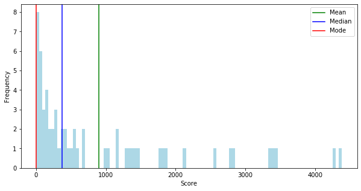

```python
mean=BasketBallData['Score'].mean()
median=BasketBallData['Score'].median()
mode=BasketBallData['Score'].mode()

print('Mean: ',mean,'\nMedian: ',median,'\nMode: ',mode[0])

plt.figure(figsize=(10,5))
plt.hist(BasketBallData['Score'],bins=100,color='lightblue')

plt.axvline(mean,color='green',label='Mean')
plt.axvline(median,color='blue',label='Median')
plt.axvline(mode[0],color='red',label='Mode')

plt.xlabel('Score')
plt.ylabel('Frequency')
plt.legend()
plt.show()
```

If Mode< Median< Mean then the distribution is positively skewed.

If Mode> Median> Mean then the distribution is negatively skewed.

From the above graph --> data is Positive skew

1. Mean of the score is below 1000 where median is below 500 which is lesser than mean
2. Mode is 0 -->0 is the most value that appeared in data

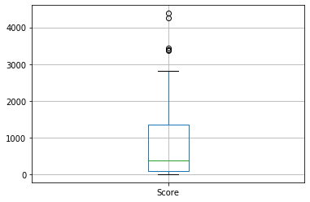

```python
# Create boxplot
BasketBallData.boxplot(column="Score")
```

Outliers are observed.

```python
BasketBallData.skew()
```

```
Tournament             1.217038
Score                  1.593109
PlayedGames            1.141978
WonGames               1.805728
DrawnGames             1.004159
LostGames              0.897130
BasketScored           1.777436
BasketGiven            0.975859
TournamentChampion     4.777021
Runner-up              4.360643
TeamLaunch             0.672956
HighestPositionHeld    0.817976
dtype: float64
```

Positive skew

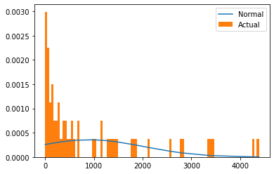

```python
plt.figure()
scores=np.asarray(BasketBallData['Score']);
NormalDistrib=stats.norm.pdf(scores,np.mean(scores),np.std(scores))
plt.plot(scores,NormalDistrib,label='Normal')
plt.hist(scores,bins=100,density=True, label='Actual')
plt.legend()
plt.show()
```

Score is positive skew with skewness score 1.593

Let us categorize team based on the team launch .

```python
BasketBallData['TeamLevel'] = (pd.qcut(BasketBallData['TeamLaunch'], 4, labels=['L4', 'L3', 'L2', 'L1']));
```

# Univarite Analysis

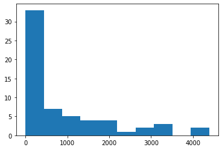

```python
plt.hist(BasketBallData.Score) ;
```

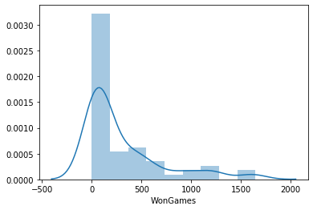

```python
sns.distplot(BasketBallData['WonGames'])
```

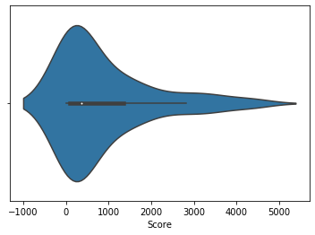

```python
sns.violinplot(BasketBallData['Score'])
```

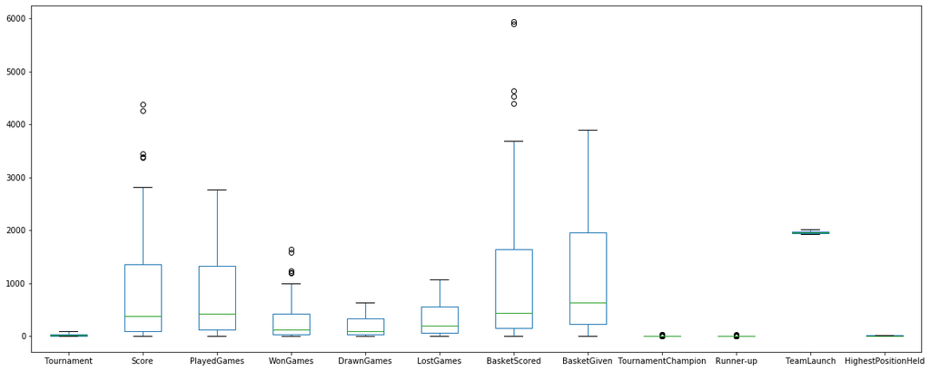

```python
BasketBallData.plot(kind='Box' ,figsize=(20,8))
```

1. Outliers are found in WonGames,score,BasketScored.
2. There is no box in TournamentChampion and Runnerup since it has been already observed 75% of data is zero
3. Most of the data is above IQR which is Right Skewed

# Finding Outliers

```python
#IQR
print("Q3----------")
print(BasketBallData['Score'].quantile(0.75))
print("IQR---------")
print(BasketBallData['Score'].quantile(0.75) - BasketBallData['Score'].quantile(0.25))
```

```
Q3----------
1351.0
IQR---------
1255.0
```

```python
IQR=1255 #score
Q3=1351 #score
Q1=89
upperfence=Q3+1.5*IQR

print("Upper Fence (Q3+1.5*IQR)=",Q3+1.5*IQR)
outliers=BasketBallData[(BasketBallData['Score']>upperfence) ]
print("No.of Outlliers = ",len(outliers))
outliers
```

```
Upper Fence (Q3+1.5*IQR)= 3233.5
No.of Outlliers =  5
```

|  | Team | Tournament | Score | PlayedGames | WonGames | DrawnGames | LostGames | BasketScored | BasketGiven | TournamentChampion | Runner-up | TeamLaunch | HighestPositionHeld | TeamLevel |
| --- | --- | --- | --- | --- | --- | --- | --- | --- | --- | --- | --- | --- | --- | --- |
| 0 | Team 1 | 86 | 4385 | 2762 | 1647 | 552 | 563 | 5947 | 3140 | 33 | 23 | 1929 | 1 | L4 |
| 1 | Team 2 | 86 | 4262 | 2762 | 1581 | 573 | 608 | 5900 | 3114 | 25 | 25 | 1929 | 1 | L4 |
| 2 | Team 3 | 80 | 3442 | 2614 | 1241 | 598 | 775 | 4534 | 3309 | 10 | 8 | 1929 | 1 | L4 |
| 3 | Team 4 | 82 | 3386 | 2664 | 1187 | 616 | 861 | 4398 | 3469 | 6 | 6 | 1931 | 1 | L4 |
| 4 | Team 5 | 86 | 3368 | 2762 | 1209 | 633 | 920 | 4631 | 3700 | 8 | 7 | 1929 | 1 | L4 |

```python
BasketBallData.drop(outliers.index, inplace=True) #Remove Outliers
BasketBallData
```

|  | Team | Tournament | Score | PlayedGames | WonGames | DrawnGames | LostGames | BasketScored | BasketGiven | TournamentChampion | Runner-up | TeamLaunch | HighestPositionHeld | TeamLevel |
| --- | --- | --- | --- | --- | --- | --- | --- | --- | --- | --- | --- | --- | --- | --- |
| 5 | Team 6 | 73 | 2819 | 2408 | 990 | 531 | 887 | 3680 | 3373 | 1 | 4 | 1934 | 1 | L4 |
| 6 | Team 7 | 82 | 2792 | 2626 | 948 | 608 | 1070 | 3609 | 3889 | 0 | 0 | 1929 | 3 | L4 |
| 7 | Team 8 | 70 | 2573 | 2302 | 864 | 577 | 861 | 3228 | 3230 | 2 | 3 | 1929 | 1 | L4 |
| 8 | Team 9 | 58 | 2109 | 1986 | 698 | 522 | 766 | 2683 | 2847 | 0 | 1 | 1939 | 2 | L3 |
| 9 | Team 10 | 51 | 1884 | 1728 | 606 | 440 | 682 | 2159 | 2492 | 1 | 0 | 1932 | 1 | L4 |
| 10 | Team 11 | 45 | 1814 | 1530 | 563 | 392 | 575 | 2052 | 2188 | 1 | 5 | 1941 | 1 | L3 |
| 11 | Team 12 | 51 | 1789 | 1698 | 586 | 389 | 723 | 2278 | 2624 | 0 | 0 | 1939 | 4 | L3 |
| 12 | Team 13 | 42 | 1471 | 1466 | 463 | 384 | 619 | 1767 | 2180 | 0 | 0 | 1948 | 4 | L3 |
| 13 | Team 14 | 44 | 1416 | 1428 | 453 | 336 | 639 | 1843 | 2368 | 0 | 1 | 1929 | 2 | L4 |
| 14 | Team 15 | 43 | 1389 | 1458 | 471 | 358 | 629 | 1753 | 2152 | 0 | 1 | 1944 | 2 | L3 |
| 15 | Team 16 | 37 | 1351 | 1318 | 426 | 327 | 565 | 1500 | 1834 | 0 | 0 | 1935 | 4 | L4 |
| 16 | Team 17 | 36 | 1314 | 1255 | 390 | 330 | 535 | 1421 | 1763 | 0 | 0 | 1949 | 4 | L3 |
| 17 | Team 18 | 38 | 1174 | 1192 | 408 | 292 | 492 | 1642 | 1951 | 0 | 0 | 1933 | 3 | L4 |
| 18 | Team 19 | 27 | 1148 | 988 | 333 | 256 | 399 | 1182 | 1371 | 0 | 0 | 1960 | 3 | L2 |
| 19 | Team 20 | 33 | 1020 | 1096 | 367 | 242 | 487 | 1347 | 1746 | 0 | 1 | 1951 | 2 | L3 |
| 20 | Team 21 | 17 | 970 | 646 | 266 | 172 | 208 | 892 | 789 | 0 | 1 | 1998 | 2 | L1 |
| 21 | Team 22 | 23 | 667 | 742 | 218 | 175 | 349 | 819 | 1157 | 0 | 0 | 1941 | 6 | L3 |
| 22 | Team 23 | 17 | 662 | 652 | 189 | 148 | 305 | 760 | 1088 | 0 | 0 | 1977 | 8 | L2 |
| 23 | Team 24 | 21 | 606 | 678 | 203 | 180 | 295 | 750 | 1022 | 0 | 0 | 1959 | 5 | L2 |
| 24 | Team 25 | 12 | 553 | 456 | 147 | 112 | 197 | 520 | 633 | 0 | 0 | 2004 | 6 | L1 |
| 25 | Team 26 | 20 | 538 | 628 | 184 | 149 | 295 | 716 | 1050 | 0 | 0 | 1935 | 5 | L4 |
| 26 | Team 27 | 13 | 510 | 494 | 155 | 128 | 211 | 619 | 744 | 0 | 0 | 1961 | 5 | L2 |
| 27 | Team 28 | 18 | 445 | 586 | 145 | 143 | 298 | 607 | 992 | 0 | 0 | 1940 | 11 | L3 |
| 28 | Team 29 | 12 | 421 | 380 | 125 | 81 | 174 | 458 | 623 | 0 | 0 | 1930 | 6 | L4 |
| 29 | Team 30 | 11 | 416 | 402 | 113 | 95 | 194 | 430 | 632 | 0 | 0 | 1963 | 6 | L2 |
| 30 | Team 31 | 12 | 375 | 423 | 123 | 102 | 198 | 422 | 581 | 0 | 0 | 1974 | 7 | L2 |
| 31 | Team 32 | 14 | 353 | 426 | 129 | 95 | 202 | 492 | 720 | 0 | 0 | 1943 | 4 | L3 |
| 32 | Team 33 | 12 | 343 | 448 | 104 | 127 | 217 | 393 | 662 | 0 | 0 | 1977 | 12 | L2 |
| 33 | Team 34 | 9 | 293 | 346 | 96 | 92 | 158 | 291 | 489 | 0 | 0 | 1987 | 7 | L1 |
| 34 | Team 35 | 11 | 285 | 334 | 103 | 79 | 152 | 419 | 588 | 0 | 0 | 1941 | 4 | L3 |
| 35 | Team 36 | 7 | 277 | 270 | 76 | 76 | 118 | 320 | 410 | 0 | 0 | 1991 | 7 | L1 |
| 36 | Team 37 | 6 | 242 | 228 | 62 | 56 | 110 | 244 | 366 | 0 | 0 | 2007 | 8 | L1 |
| 37 | Team 38 | 9 | 230 | 282 | 82 | 63 | 137 | 285 | 430 | 0 | 0 | 1962 | 5 | L2 |
| 38 | Team 39 | 4 | 190 | 160 | 52 | 45 | 63 | 199 | 241 | 0 | 0 | 1994 | 10 | L1 |
| 39 | Team 40 | 5 | 188 | 186 | 50 | 46 | 90 | 202 | 296 | 0 | 0 | 1978 | 8 | L2 |
| 40 | Team 41 | 6 | 168 | 204 | 59 | 50 | 95 | 216 | 310 | 0 | 0 | 1971 | 12 | L2 |
| 41 | Team 42 | 6 | 150 | 180 | 53 | 44 | 83 | 165 | 221 | 0 | 0 | 1963 | 7 | L2 |
| 42 | Team 43 | 4 | 148 | 152 | 37 | 37 | 78 | 155 | 253 | 0 | 0 | 1999 | 17 | L1 |
| 43 | Team 44 | 3 | 132 | 114 | 35 | 27 | 52 | 139 | 167 | 0 | 0 | 2014 | 10 | L1 |
| 44 | Team 45 | 7 | 107 | 130 | 43 | 21 | 66 | 227 | 308 | 0 | 0 | 1929 | 3 | L4 |
| 45 | Team 46 | 3 | 96 | 114 | 26 | 44 | 44 | 101 | 139 | 0 | 0 | 1990 | 9 | L1 |
| 46 | Team 47 | 4 | 91 | 116 | 34 | 16 | 66 | 181 | 295 | 0 | 0 | 1947 | 7 | L3 |
| 47 | Team 48 | 2 | 83 | 80 | 20 | 23 | 37 | 62 | 117 | 0 | 0 | 1996 | 17 | L1 |
| 48 | Team 49 | 2 | 81 | 80 | 19 | 24 | 37 | 70 | 115 | 0 | 0 | 1995 | 19 | L1 |
| 49 | Team 50 | 4 | 76 | 108 | 30 | 16 | 62 | 145 | 252 | 0 | 0 | 1945 | 10 | L3 |
| 50 | Team 51 | 3 | 71 | 90 | 29 | 13 | 48 | 121 | 183 | 0 | 0 | 1953 | 14 | L2 |
| 51 | Team 52 | 4 | 56 | 72 | 21 | 14 | 37 | 153 | 184 | 0 | 0 | 1929 | 6 | L4 |
| 52 | Team 53 | 2 | 52 | 68 | 17 | 18 | 33 | 71 | 116 | 0 | 0 | 1979 | 10 | L1 |
| 53 | Team 54 | 3 | 42 | 54 | 18 | 6 | 30 | 97 | 131 | 0 | 0 | 1929 | 8 | L4 |
| 54 | Team 55 | 2 | 40 | 68 | 13 | 14 | 41 | 70 | 182 | 0 | 0 | 1950 | 16 | L3 |
| 55 | Team 56 | 1 | 35 | 38 | 8 | 11 | 19 | 36 | 55 | 0 | 0 | 2016 | 17 | L1 |
| 56 | Team 57 | 1 | 34 | 38 | 8 | 10 | 20 | 38 | 66 | 0 | 0 | 2009 | 20 | L1 |
| 57 | Team 58 | 1 | 22 | 30 | 7 | 8 | 15 | 37 | 57 | 0 | 0 | 1956 | 16 | L2 |
| 58 | Team 59 | 1 | 19 | 30 | 7 | 5 | 18 | 51 | 85 | 0 | 0 | 1951 | 16 | L3 |
| 59 | Team 60 | 1 | 14 | 30 | 5 | 4 | 21 | 34 | 65 | 0 | 0 | 1955 | 15 | L2 |
| 60 | Team 61 | 1 | 0 | 0 | 0 | 0 | 0 | 0 | 0 | 0 | 0 | 2017 | 9 | L1 |

# BiVariate Analysis

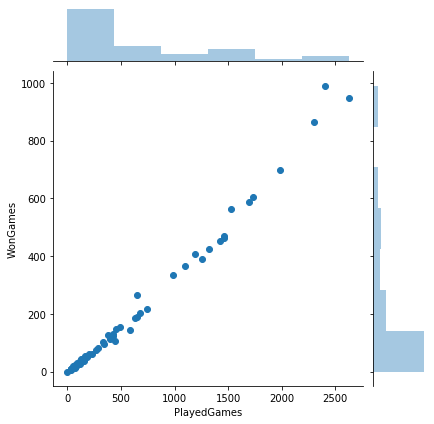

```python
sns.jointplot(BasketBallData['PlayedGames'],BasketBallData['WonGames'])
```

WonGames is directly Proportional to PlayedGames, So to get the performance we must find the Win rate. some may played less games But performed well in all the games participated. Hence need to find win rate and lost rate.

# Performance Analysis

```python
DataCleanOriginal=BasketBallData.copy(deep='True')
BasketBallData['WinRate']=(BasketBallData.WonGames/ BasketBallData.PlayedGames)*100
BasketBallData['DrawnRate']=(BasketBallData.DrawnGames/ BasketBallData.PlayedGames)*100
BasketBallData['LostRate']=(BasketBallData.LostGames/ BasketBallData.PlayedGames)*100
Top15team=BasketBallData[['Team','TeamLaunch','TeamLevel','Score','WinRate','LostRate','DrawnRate']].sort_values(by= ['WinRate'],ascending =False)[:15]
Top15team  # after removing Outliers
```

|  | Team | TeamLaunch | TeamLevel | Score | WinRate | LostRate | DrawnRate |
| --- | --- | --- | --- | --- | --- | --- | --- |
| 20 | Team 21 | 1998 | L1 | 970 | 41.176471 | 32.198142 | 26.625387 |
| 5 | Team 6 | 1934 | L4 | 2819 | 41.112957 | 36.835548 | 22.051495 |
| 7 | Team 8 | 1929 | L4 | 2573 | 37.532580 | 37.402259 | 25.065161 |
| 10 | Team 11 | 1941 | L3 | 1814 | 36.797386 | 37.581699 | 25.620915 |
| 6 | Team 7 | 1929 | L4 | 2792 | 36.100533 | 40.746382 | 23.153085 |
| 8 | Team 9 | 1939 | L3 | 2109 | 35.146022 | 38.569990 | 26.283988 |
| 9 | Team 10 | 1932 | L4 | 1884 | 35.069444 | 39.467593 | 25.462963 |
| 11 | Team 12 | 1939 | L3 | 1789 | 34.511190 | 42.579505 | 22.909305 |
| 17 | Team 18 | 1933 | L4 | 1174 | 34.228188 | 41.275168 | 24.496644 |
| 18 | Team 19 | 1960 | L2 | 1148 | 33.704453 | 40.384615 | 25.910931 |
| 19 | Team 20 | 1951 | L3 | 1020 | 33.485401 | 44.434307 | 22.080292 |
| 53 | Team 54 | 1929 | L4 | 42 | 33.333333 | 55.555556 | 11.111111 |
| 44 | Team 45 | 1929 | L4 | 107 | 33.076923 | 50.769231 | 16.153846 |
| 28 | Team 29 | 1930 | L4 | 421 | 32.894737 | 45.789474 | 21.315789 |
| 38 | Team 39 | 1994 | L1 | 190 | 32.500000 | 39.375000 | 28.125000 |

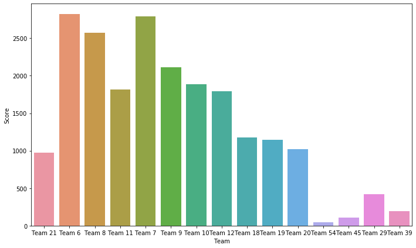

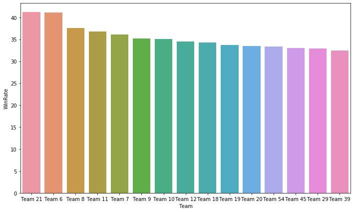

```python
plt.subplots(figsize=(10,6))
sns.barplot(Top15team['Team'],Top15team['Score'])
plt.tight_layout()
plt.show()
plt.subplots(figsize=(10,6))
sns.barplot(Top15team['Team'],Top15team['WinRate'])
plt.tight_layout()
```

Team 21 and Team 11 score is less But their win rate is high . Since they played less games their score might be low . but they played well in the game they participated

# MultiVariate Analysis

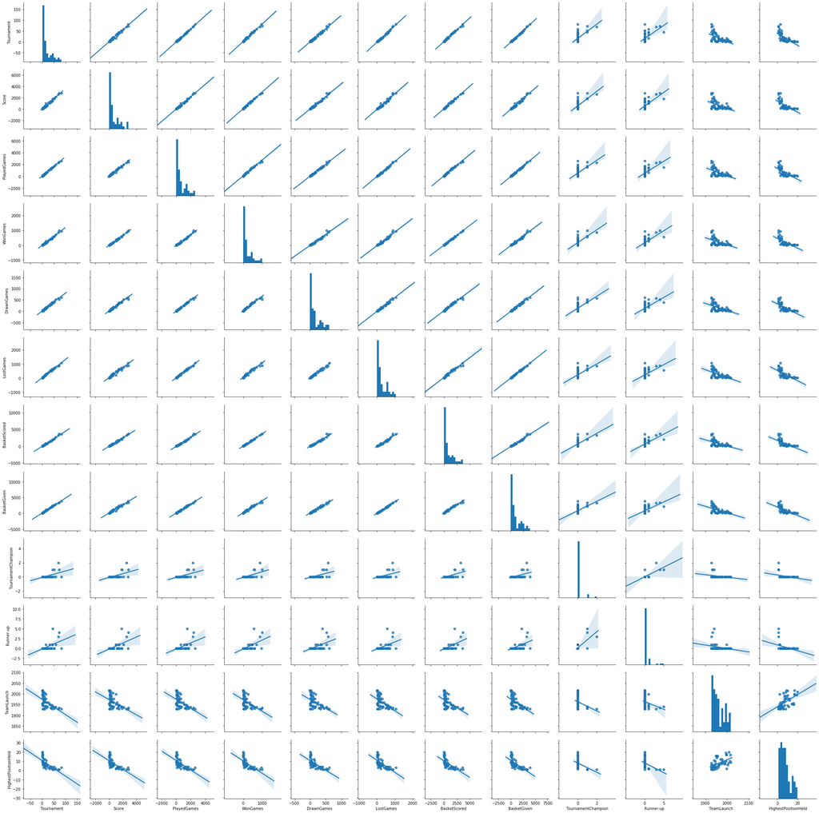

```python
#pairplot to check correleation
sns.pairplot(DataCleanOriginal, kind="reg")  # plots scatter plots for every pair of attributes and histograms along the diagonal
plt.show()
```

From the pair plot , it is observed that WonGames,PlayedGames and basket scored are higly correlated

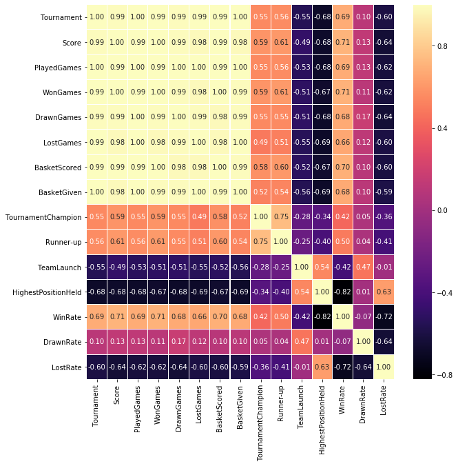

```python
fig,ax = plt.subplots(figsize=(10, 10))
sns.heatmap(BasketBallData.corr(), ax=ax, annot=True, linewidths=0.05, fmt= '.2f',cmap="magma") # the color intensity is based on
plt.show()
```

From the heat map . Won games,Score and BasketScored are perfect correlated with (1.0) Tournament and Played Games are also Perfect correlated (1.0)

## Best Team

```python
#best Team after dropping Outliers
BasketBallData[(BasketBallData.WinRate==BasketBallData.WinRate.max()) & (BasketBallData.LostRate==BasketBallData.LostRate.min() )]
```

|  | Team | Tournament | Score | PlayedGames | WonGames | DrawnGames | LostGames | BasketScored | BasketGiven | TournamentChampion | Runner-up | TeamLaunch | HighestPositionHeld | TeamLevel | WinRate | DrawnRate | LostRate |
| --- | --- | --- | --- | --- | --- | --- | --- | --- | --- | --- | --- | --- | --- | --- | --- | --- | --- |
| 20 | Team 21 | 17 | 970 | 646 | 266 | 172 | 208 | 892 | 789 | 0 | 1 | 1998 | 2 | L1 | 41.176471 | 26.625387 | 32.198142 |

## Least Performer

```python
BasketBallData.sort_values(by= ['WinRate'],ascending =True).head(2)
```

|  | Team | Tournament | Score | PlayedGames | WonGames | DrawnGames | LostGames | BasketScored | BasketGiven | TournamentChampion | Runner-up | TeamLaunch | HighestPositionHeld | TeamLevel | WinRate | DrawnRate | LostRate |
| --- | --- | --- | --- | --- | --- | --- | --- | --- | --- | --- | --- | --- | --- | --- | --- | --- | --- |
| 59 | Team 60 | 1 | 14 | 30 | 5 | 4 | 21 | 34 | 65 | 0 | 0 | 1955 | 15 | L2 | 16.666667 | 13.333333 | 70.000000 |
| 54 | Team 55 | 2 | 40 | 68 | 13 | 14 | 41 | 70 | 182 | 0 | 0 | 1950 | 16 | L3 | 19.117647 | 20.588235 | 60.294118 |

## Best in New team

```python
BasketBallData[(BasketBallData.TeamLevel=='L1')].sort_values(by='WinRate', ascending=False).head(3)
```

|  | Team | Tournament | Score | PlayedGames | WonGames | DrawnGames | LostGames | BasketScored | BasketGiven | TournamentChampion | Runner-up | TeamLaunch | HighestPositionHeld | TeamLevel | WinRate | DrawnRate | LostRate |
| --- | --- | --- | --- | --- | --- | --- | --- | --- | --- | --- | --- | --- | --- | --- | --- | --- | --- |
| 20 | Team 21 | 17 | 970 | 646 | 266 | 172 | 208 | 892 | 789 | 0 | 1 | 1998 | 2 | L1 | 41.176471 | 26.625387 | 32.198142 |
| 38 | Team 39 | 4 | 190 | 160 | 52 | 45 | 63 | 199 | 241 | 0 | 0 | 1994 | 10 | L1 | 32.500000 | 28.125000 | 39.375000 |
| 24 | Team 25 | 12 | 553 | 456 | 147 | 112 | 197 | 520 | 633 | 0 | 0 | 2004 | 6 | L1 | 32.236842 | 24.561404 | 43.201754 |

## Top15Team without Outliers

```python
Top15team
```

|  | Team | TeamLaunch | TeamLevel | Score | WinRate | LostRate | DrawnRate |
| --- | --- | --- | --- | --- | --- | --- | --- |
| 20 | Team 21 | 1998 | L1 | 970 | 41.176471 | 32.198142 | 26.625387 |
| 5 | Team 6 | 1934 | L4 | 2819 | 41.112957 | 36.835548 | 22.051495 |
| 7 | Team 8 | 1929 | L4 | 2573 | 37.532580 | 37.402259 | 25.065161 |
| 10 | Team 11 | 1941 | L3 | 1814 | 36.797386 | 37.581699 | 25.620915 |
| 6 | Team 7 | 1929 | L4 | 2792 | 36.100533 | 40.746382 | 23.153085 |
| 8 | Team 9 | 1939 | L3 | 2109 | 35.146022 | 38.569990 | 26.283988 |
| 9 | Team 10 | 1932 | L4 | 1884 | 35.069444 | 39.467593 | 25.462963 |
| 11 | Team 12 | 1939 | L3 | 1789 | 34.511190 | 42.579505 | 22.909305 |
| 17 | Team 18 | 1933 | L4 | 1174 | 34.228188 | 41.275168 | 24.496644 |
| 18 | Team 19 | 1960 | L2 | 1148 | 33.704453 | 40.384615 | 25.910931 |
| 19 | Team 20 | 1951 | L3 | 1020 | 33.485401 | 44.434307 | 22.080292 |
| 53 | Team 54 | 1929 | L4 | 42 | 33.333333 | 55.555556 | 11.111111 |
| 44 | Team 45 | 1929 | L4 | 107 | 33.076923 | 50.769231 | 16.153846 |
| 28 | Team 29 | 1930 | L4 | 421 | 32.894737 | 45.789474 | 21.315789 |
| 38 | Team 39 | 1994 | L1 | 190 | 32.500000 | 39.375000 | 28.125000 |

## Team who Have more Drawn Games

```python
BasketBallData.sort_values(['DrawnRate'],ascending=[False]).head(1)
```

|  | Team | Tournament | Score | PlayedGames | WonGames | DrawnGames | LostGames | BasketScored | BasketGiven | TournamentChampion | Runner-up | TeamLaunch | HighestPositionHeld | TeamLevel | WinRate | DrawnRate | LostRate |
| --- | --- | --- | --- | --- | --- | --- | --- | --- | --- | --- | --- | --- | --- | --- | --- | --- | --- |
| 45 | Team 46 | 3 | 96 | 114 | 26 | 44 | 44 | 101 | 139 | 0 | 0 | 1990 | 9 | L1 | 22.807018 | 38.596491 | 38.596491 |

T1,T2,T3,T4 and T5 are outliers as found above.

# Recommended Teams for Company X

```python
bestteams=['Team 6','Team 7','Team 8','Team 9','Team 10','Team 11','Team 12','Team 18','Team 19','Team 20','Team 21','Team 46']

RecommendedTeam=BasketBallData[BasketBallData['Team'].isin(bestteams)]
RecommendedTeam=RecommendedTeam[['Team','TeamLevel','PlayedGames','WonGames','LostGames','DrawnGames','WinRate','LostRate','DrawnRate','TournamentChampion','HighestPositionHeld']].sort_values(by='WinRate', ascending=False)
RecommendedTeam
```

|  | Team | TeamLevel | PlayedGames | WonGames | LostGames | DrawnGames | WinRate | LostRate | DrawnRate | TournamentChampion | HighestPositionHeld |
| --- | --- | --- | --- | --- | --- | --- | --- | --- | --- | --- | --- |
| 20 | Team 21 | L1 | 646 | 266 | 208 | 172 | 41.176471 | 32.198142 | 26.625387 | 0 | 2 |
| 5 | Team 6 | L4 | 2408 | 990 | 887 | 531 | 41.112957 | 36.835548 | 22.051495 | 1 | 1 |
| 7 | Team 8 | L4 | 2302 | 864 | 861 | 577 | 37.532580 | 37.402259 | 25.065161 | 2 | 1 |
| 10 | Team 11 | L3 | 1530 | 563 | 575 | 392 | 36.797386 | 37.581699 | 25.620915 | 1 | 1 |
| 6 | Team 7 | L4 | 2626 | 948 | 1070 | 608 | 36.100533 | 40.746382 | 23.153085 | 0 | 3 |
| 8 | Team 9 | L3 | 1986 | 698 | 766 | 522 | 35.146022 | 38.569990 | 26.283988 | 0 | 2 |
| 9 | Team 10 | L4 | 1728 | 606 | 682 | 440 | 35.069444 | 39.467593 | 25.462963 | 1 | 1 |
| 11 | Team 12 | L3 | 1698 | 586 | 723 | 389 | 34.511190 | 42.579505 | 22.909305 | 0 | 4 |
| 17 | Team 18 | L4 | 1192 | 408 | 492 | 292 | 34.228188 | 41.275168 | 24.496644 | 0 | 3 |
| 18 | Team 19 | L2 | 988 | 333 | 399 | 256 | 33.704453 | 40.384615 | 25.910931 | 0 | 3 |
| 19 | Team 20 | L3 | 1096 | 367 | 487 | 242 | 33.485401 | 44.434307 | 22.080292 | 0 | 2 |
| 45 | Team 46 | L1 | 114 | 26 | 44 | 44 | 22.807018 | 38.596491 | 38.596491 | 0 | 9 |

# If competitor is already in Contract with L4 Teams, choose below tem

```python
#The above teams are recommended for companyx

#If the competitor already have contract with L4 then the below team can be chosen

RecommendedTeam_1=RecommendedTeam[(RecommendedTeam.TeamLevel!='L4')]
RecommendedTeam_1
```

|  | Team | TeamLevel | PlayedGames | WonGames | LostGames | DrawnGames | WinRate | LostRate | DrawnRate | TournamentChampion | HighestPositionHeld |
| --- | --- | --- | --- | --- | --- | --- | --- | --- | --- | --- | --- |
| 20 | Team 21 | L1 | 646 | 266 | 208 | 172 | 41.176471 | 32.198142 | 26.625387 | 0 | 2 |
| 10 | Team 11 | L3 | 1530 | 563 | 575 | 392 | 36.797386 | 37.581699 | 25.620915 | 1 | 1 |
| 8 | Team 9 | L3 | 1986 | 698 | 766 | 522 | 35.146022 | 38.569990 | 26.283988 | 0 | 2 |
| 11 | Team 12 | L3 | 1698 | 586 | 723 | 389 | 34.511190 | 42.579505 | 22.909305 | 0 | 4 |
| 18 | Team 19 | L2 | 988 | 333 | 399 | 256 | 33.704453 | 40.384615 | 25.910931 | 0 | 3 |
| 19 | Team 20 | L3 | 1096 | 367 | 487 | 242 | 33.485401 | 44.434307 | 22.080292 | 0 | 2 |
| 45 | Team 46 | L1 | 114 | 26 | 44 | 44 | 22.807018 | 38.596491 | 38.596491 | 0 | 9 |

3.Please include any improvements or suggestions to the association management on quality, quantity, variety, velocity, veracity etc. on the data points collected by the association to perform a better data analysis in future. At-least 1 suggestion for each point.

## Quality:

Missing Team information for Team 61 only highest poistion held is found , No data about the players.

## Quantity:

With team information having all the old and new team launch we cant predict the winning rate. providing player information and the age of the players whether the team is still active in tournaments those data can be added.

## Variety:

Number of times the highestposition held and total fouls made can be mentioned.

## Veracity:

Data is small. and the wonGames,basketscore and score all the 3 columns are interrelated moreover gives same set of outputs and the data have Outliers and missing informations too there is a probability of arriving at wrong assumptions and predictions.

## Missing information:

Team launch information is there but the very old team in the data is still active and is there any change in the player list over a period of time is needed to analyze the strength of the team and also to decide whether that team can be taken into consideration.

Add player details , No.of times Highest position held, Active status of the team.

# PART-C

PROJECT OBJECTIVE: Analyse the data of the various companies from the given dataset and perform the tasks that are specified in the below steps. Draw insights from the various attributes that are present in the dataset, plot distributions, state hypotheses and draw conclusions from the dataset

1. Read the CSV file.
2. Data Exploration:

```python
Startupdata=pd.read_csv("C:\\Users\\AN953317\\Downloads\\CompanyX_EU.csv")
Startupdata
```

|  | Startup | Product | Funding | Event | Result | OperatingState |
| --- | --- | --- | --- | --- | --- | --- |
| 0 | 2600Hz | 2600hz.com | NaN | Disrupt SF 2013 | Contestant | Operating |
| 1 | 3DLT | 3dlt.com | $630K | Disrupt NYC 2013 | Contestant | Closed |
| 2 | 3DPrinterOS | 3dprinteros.com | NaN | Disrupt SF 2016 | Contestant | Operating |
| 3 | 3Dprintler | 3dprintler.com | $1M | Disrupt NY 2016 | Audience choice | Operating |
| 4 | 42 Technologies | 42technologies.com | NaN | Disrupt NYC 2013 | Contestant | Operating |
| 5 | 5to1 | 5to1.com | $19.3M | TC50 2009 | Contestant | Acquired |
| 6 | 8 Securities | 8securities.com | $29M | Disrupt Beijing 2011 | Finalist | Operating |
| 7 | 8020 Media | 8020media.com | NaN | TC40 2007 | Contestant | Operating |
| 8 | About Last Night | aboutlastnight.net | NaN | Disrupt NYC 2012 | Contestant | Operating |
| 9 | Adgregate Markets | adgregate.com | NaN | TC50 2008 | Contestant | Operating |
| 10 | AdhereTech | adheretech.com | $1.8M | Hardware Battlefield 2014 | Contestant | Operating |
| 11 | AdRocket | adrocket.com | $1M | TC50 2008 | Contestant | Closed |
| 12 | Affective Interfaces | affectiveinterfaces.com | NaN | TC50 2009 | Contestant | Operating |
| 13 | Agrilyst | agrilyst.com | $1M | Disrupt SF 2015 | Winner | Operating |
| 14 | Aiden | aiden.ai | $750K | Disrupt London 2016 | Contestant | Operating |
| 15 | AirBoxLab | foobot.io | $17.9K | Hardware Battlefield 2014 | Contestant | Operating |
| 16 | Aircall | aircall.io | $11.6M | Disrupt SF 2015 | Contestant | Operating |
| 17 | AirDroids | airdroids.com | $929.2K | Hardware Battlefield 2014 | Contestant | Closed |
| 18 | AirHelp | airhelp.com | $12.2M | Disrupt NYC 2014 | Contestant | Operating |
| 19 | AirWander | airwander.com | NaN | Disrupt London 2016 | Contestant | Operating |
| 20 | Akoha | akoha.com | $1.9M | TC50 2008 | Contestant | Closed |
| 21 | Alfabetic | alfabetic.com | NaN | TC50 2008 | Contestant | Acquired |
| 22 | Alicanto | alicanto.com | $4M | Disrupt SF 2012 | Contestant | Operating |
| 23 | Allre | allre.com | NaN | Disrupt SF 2014 | Contestant | Acquired |
| 24 | Alpha Outlook | alphaoutlook.com | NaN | Disrupt Beijing 2011 | Contestant | Operating |
| 25 | Altwork | altwork.com | NaN | Disrupt SF 2016 | Audience choice | Operating |
| 26 | Amaryllis Nucleics | amaryllisnucleics.com | NaN | Disrupt SF 2016 | Contestant | Operating |
| 27 | Amen. | getamen.com | $3M | Disrupt SF 2011 | Contestant | Acquired |
| 28 | Angstro | angst.ro | $225K | TC50 2008 | Contestant | Acquired |
| 29 | Anquanbao | anquanbao.com | NaN | Disrupt Beijing 2011 | Runner up | Acquired |
| ... | ... | ... | ... | ... | ... | ... |
| 632 | WeDemand | wedemand.com | $1M | Disrupt SF 2012 | Contestant | Operating |
| 633 | Wellth | wellthapp.com | $2.5M | Disrupt NY 2015 | Contestant | Operating |
| 634 | Wellthy | wellthy.com | $2M | Disrupt SF 2015 | Contestant | Operating |
| 635 | Welltwigs | welltwigs.com | $50K | Disrupt NY 2015 | Contestant | Operating |
| 636 | Weotta | weotta.com | NaN | Disrupt NYC 2011 | Contestant | Operating |
| 637 | What Now Travel | whatnowtravel.com | NaN | Disrupt EU 2013 | Contestant | Operating |
| 638 | Wiivv | wiivv.com | $12.2M | Hardware Battlefield 2016 | Runner up | Operating |
| 639 | Wixi | wixi.com | NaN | TC40 2007 | Contestant | Closed |
| 640 | WooMe | woome.com | $17.4M | TC40 2007 | Finalist | Acquired |
| 641 | Workspot | workspot.com | $15.8M | Disrupt NYC 2013 | Contestant | Operating |
| 642 | Xendo | xendo.com | $28K | Disrupt SF 2014 | Contestant | Acquired |
| 643 | Xobni | yahoo.com | $41.8M | TC40 2007 | Contestant | Acquired |
| 644 | Yammer | yammer.com | $142M | TC50 2008 | Winner | Acquired |
| 645 | Yap | yapme.com | $10M | TC40 2007 | Contestant | Closed |
| 646 | YayPay Inc | yaypay.com | $900K | Disrupt London 2015 | Contestant | Operating |
| 647 | Yext | yext.com | $117.8M | TC50 2009 | Contestant | Ipo |
| 648 | YOOBIC | yoobic.com | NaN | Disrupt London 2015 | Finalist | Operating |
| 649 | YouNow | younow.com | $26M | Disrupt SF 2011 | Contestant | Operating |
| 650 | YourMechanic | yourmechanic.com | $28M | Disrupt SF 2012 | Winner | Operating |
| 651 | YourVersion | yourversion.com | NaN | TC50 2009 | Audience choice | Operating |
| 652 | Yuwan | iyuwan.cn | NaN | Disrupt Beijing 2011 | Contestant | Closed |
| 653 | ZAP! | zapreklam.com/ | NaN | Disrupt EU 2014 | Audience choice | Operating |
| 654 | ZEFR | zefr.com | $62.1M | Disrupt NYC 2010 | Contestant | Operating |
| 655 | Zello | zello.com | NaN | TC40 2007 | Contestant | Operating |
| 656 | Zenefits | zenefits.com | $583.6M | Disrupt NYC 2013 | Finalist | Operating |
| 657 | Zivity | zivity.com | $8M | TC40 2007 | Contestant | Operating |
| 658 | Zmorph | zmorph3d.com | $1M | - | Audience choice | Operating |
| 659 | Zocdoc | zocdoc.com | $223M | TC40 2007 | Contestant | Operating |
| 660 | Zula | zulaapp.com | $3.4M | Disrupt SF 2013 | Audience choice | Operating |
| 661 | Zumper | zumper.com | $31.5M | Disrupt SF 2012 | Finalist | Operating |

662 rows × 6 columns

```python
#2A. Check the datatypes of each attribute.
Startupdata.info()
```

```
<class 'pandas.core.frame.DataFrame'>
RangeIndex: 662 entries, 0 to 661
Data columns (total 6 columns):
Startup           662 non-null object
Product           656 non-null object
Funding           448 non-null object
Event             662 non-null object
Result            662 non-null object
OperatingState    662 non-null object
dtypes: object(6)
memory usage: 31.1+ KB
```

```python
#2B. Check for null values in the attributes
Startupdata.isnull().sum()
```

```
Startup             0
Product             6
Funding           214
Event               0
Result              0
OperatingState      0
dtype: int64
```

3.Data preprocessing & visualisation:

```python
#3A. Drop the null values.
Startupdata=Startupdata.dropna()
Startupdata
```

|  | Startup | Product | Funding | Event | Result | OperatingState |
| --- | --- | --- | --- | --- | --- | --- |
| 1 | 3DLT | 3dlt.com | $630K | Disrupt NYC 2013 | Contestant | Closed |
| 3 | 3Dprintler | 3dprintler.com | $1M | Disrupt NY 2016 | Audience choice | Operating |
| 5 | 5to1 | 5to1.com | $19.3M | TC50 2009 | Contestant | Acquired |
| 6 | 8 Securities | 8securities.com | $29M | Disrupt Beijing 2011 | Finalist | Operating |
| 10 | AdhereTech | adheretech.com | $1.8M | Hardware Battlefield 2014 | Contestant | Operating |
| 11 | AdRocket | adrocket.com | $1M | TC50 2008 | Contestant | Closed |
| 13 | Agrilyst | agrilyst.com | $1M | Disrupt SF 2015 | Winner | Operating |
| 14 | Aiden | aiden.ai | $750K | Disrupt London 2016 | Contestant | Operating |
| 15 | AirBoxLab | foobot.io | $17.9K | Hardware Battlefield 2014 | Contestant | Operating |
| 16 | Aircall | aircall.io | $11.6M | Disrupt SF 2015 | Contestant | Operating |
| 17 | AirDroids | airdroids.com | $929.2K | Hardware Battlefield 2014 | Contestant | Closed |
| 18 | AirHelp | airhelp.com | $12.2M | Disrupt NYC 2014 | Contestant | Operating |
| 20 | Akoha | akoha.com | $1.9M | TC50 2008 | Contestant | Closed |
| 22 | Alicanto | alicanto.com | $4M | Disrupt SF 2012 | Contestant | Operating |
| 27 | Amen. | getamen.com | $3M | Disrupt SF 2011 | Contestant | Acquired |
| 28 | Angstro | angst.ro | $225K | TC50 2008 | Contestant | Acquired |
| 31 | Anyclip | anyclip.com | $24M | TC50 2009 | Finalist | Operating |
| 32 | App2you | app2you.com | $746K | TC40 2007 | Contestant | Operating |
| 34 | Appbistro | appbistro.com | $600K | Disrupt NYC 2010 | Contestant | Closed |
| 35 | AppChina | appchina.com | $7.1M | Disrupt Beijing 2011 | Contestant | Operating |
| 37 | Ark | ark.com | $4.5M | Disrupt NYC 2012 | Finalist | Operating |
| 40 | Artsy | artsy.net | $50.9M | Disrupt NYC 2010 | Contestant | Operating |
| 42 | asap54.com | asap54.com | $8.3M | Disrupt EU 2013 | Runner up | Operating |
| 44 | Atlas Wearables | atlaswearables.com | $4M | Hardware Battlefield 2014 | Finalist | Operating |
| 46 | Ava | avawomen.com | $12.3M | Disrupt SF 2015 | Contestant | Operating |
| 47 | Avado | avado.com | $1M | Disrupt NYC 2011 | Contestant | Acquired |
| 48 | Babelverse | babelverse.com | $190K | Disrupt NYC 2012 | Audience choice | Closed |
| 49 | Badgeville | badgeville.com | $40M | Disrupt SF 2010 | Finalist | Acquired |
| 51 | Beam | beam.pro | $520K | Disrupt NY 2016 | Winner | Acquired |
| 52 | Beartooth | beartooth.com | $2.9M | Disrupt SF 2014 | Contestant | Operating |
| ... | ... | ... | ... | ... | ... | ... |
| 623 | Voltera | voltera.io | $55K | Hardware Battlefield 2015 | Winner | Operating |
| 624 | Voxel | voxel.net | $7.1M | Disrupt SF 2013 | Contestant | Operating |
| 625 | Voxy | voxy.com | $30.8M | Disrupt SF 2010 | Contestant | Operating |
| 626 | Vurb | vurb.com | $10M | Disrupt NYC 2014 | Winner | Acquired |
| 628 | Wanderio | wanderio.com | $275K | Disrupt EU 2013 | Contestant | Operating |
| 629 | WaterO | wateropurifier.com | $85.7K | Disrupt NY 2016 | Runner up | Operating |
| 630 | WAZER | wazer.com | $1.4M | Disrupt SF 2016 | Contestant | Operating |
| 631 | WEconnect | weconnectrecovery.com | $2.1M | Disrupt SF 2016 | Audience choice | Operating |
| 632 | WeDemand | wedemand.com | $1M | Disrupt SF 2012 | Contestant | Operating |
| 633 | Wellth | wellthapp.com | $2.5M | Disrupt NY 2015 | Contestant | Operating |
| 634 | Wellthy | wellthy.com | $2M | Disrupt SF 2015 | Contestant | Operating |
| 635 | Welltwigs | welltwigs.com | $50K | Disrupt NY 2015 | Contestant | Operating |
| 638 | Wiivv | wiivv.com | $12.2M | Hardware Battlefield 2016 | Runner up | Operating |
| 640 | WooMe | woome.com | $17.4M | TC40 2007 | Finalist | Acquired |
| 641 | Workspot | workspot.com | $15.8M | Disrupt NYC 2013 | Contestant | Operating |
| 642 | Xendo | xendo.com | $28K | Disrupt SF 2014 | Contestant | Acquired |
| 643 | Xobni | yahoo.com | $41.8M | TC40 2007 | Contestant | Acquired |
| 644 | Yammer | yammer.com | $142M | TC50 2008 | Winner | Acquired |
| 645 | Yap | yapme.com | $10M | TC40 2007 | Contestant | Closed |
| 646 | YayPay Inc | yaypay.com | $900K | Disrupt London 2015 | Contestant | Operating |
| 647 | Yext | yext.com | $117.8M | TC50 2009 | Contestant | Ipo |
| 649 | YouNow | younow.com | $26M | Disrupt SF 2011 | Contestant | Operating |
| 650 | YourMechanic | yourmechanic.com | $28M | Disrupt SF 2012 | Winner | Operating |
| 654 | ZEFR | zefr.com | $62.1M | Disrupt NYC 2010 | Contestant | Operating |
| 656 | Zenefits | zenefits.com | $583.6M | Disrupt NYC 2013 | Finalist | Operating |
| 657 | Zivity | zivity.com | $8M | TC40 2007 | Contestant | Operating |
| 658 | Zmorph | zmorph3d.com | $1M | - | Audience choice | Operating |
| 659 | Zocdoc | zocdoc.com | $223M | TC40 2007 | Contestant | Operating |
| 660 | Zula | zulaapp.com | $3.4M | Disrupt SF 2013 | Audience choice | Operating |
| 661 | Zumper | zumper.com | $31.5M | Disrupt SF 2012 | Finalist | Operating |

446 rows × 6 columns

```python
#After dropping Null
Startupdata.info()
```

```
<class 'pandas.core.frame.DataFrame'>
Int64Index: 446 entries, 1 to 661
Data columns (total 6 columns):
Startup           446 non-null object
Product           446 non-null object
Funding           446 non-null object
Event             446 non-null object
Result            446 non-null object
OperatingState    446 non-null object
dtypes: object(6)
memory usage: 24.4+ KB
```

```python
#After dropping Null
Startupdata.isna().sum()
```

```
Startup           0
Product           0
Funding           0
Event             0
Result            0
OperatingState    0
dtype: int64
```

```python
#3B. Convert the ‘Funding’ features to a numerical value.
#(Execute below code)
Startupdata.loc[:,'Funds_in_million'] = Startupdata['Funding'].apply(lambda x: float(x[1:-1])/1000 if x[-1] == 'K' else (float(x[1:-1])*1000 if x[-1] == 'B' else float(x[1:-1])))
Startupdata.head()
```

|  | Startup | Product | Funding | Event | Result | OperatingState | Funds_in_million |
| --- | --- | --- | --- | --- | --- | --- | --- |
| 1 | 3DLT | 3dlt.com | $630K | Disrupt NYC 2013 | Contestant | Closed | 0.63 |
| 3 | 3Dprintler | 3dprintler.com | $1M | Disrupt NY 2016 | Audience choice | Operating | 1.00 |
| 5 | 5to1 | 5to1.com | $19.3M | TC50 2009 | Contestant | Acquired | 19.30 |
| 6 | 8 Securities | 8securities.com | $29M | Disrupt Beijing 2011 | Finalist | Operating | 29.00 |
| 10 | AdhereTech | adheretech.com | $1.8M | Hardware Battlefield 2014 | Contestant | Operating | 1.80 |

[figure not shown]

```python
#3C. Plot box plot for funds in million.
Startupdata.boxplot(column='Funds_in_million',figsize=(5,7))
```

```python
#3D. Check the number of outliers greater than the upper fence.
Startupdata['Funds_in_million'].describe(include='all')
Startupdata.info()
```

```
<class 'pandas.core.frame.DataFrame'>
Int64Index: 446 entries, 1 to 661
Data columns (total 7 columns):
Startup             446 non-null object
Product             446 non-null object
Funding             446 non-null object
Event               446 non-null object
Result              446 non-null object
OperatingState      446 non-null object
Funds_in_million    446 non-null float64
dtypes: float64(1), object(6)
memory usage: 27.9+ KB
```

```python
Q3=9.47500
Q1=0.74525
IQR=Q3-Q1
IQR
upperfence=Q3+1.5*IQR

print("Upper Fence (Q3+1.5*IQR)=",Q3+1.5*IQR)

startupoutliers=Startupdata[(Startupdata['Funds_in_million']>upperfence)]
print("No.of Outlliers = ",len(startupoutliers))
```

```
Upper Fence (Q3+1.5*IQR)= 22.569625
No.of Outlliers =  60
```

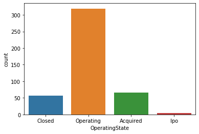

```python
#3E. Check frequency of the OperatingState features classes.
sns.countplot(x='OperatingState',data=Startupdata)
```

```python
Startupdata['OperatingState'].value_counts()
```

```
Operating    319
Acquired      66
Closed        57
Ipo            4
Name: OperatingState, dtype: int64
```

```python
#drop Outliers

Startupdata.drop(startupoutliers.index, inplace=True)
```

4.Statistical Analysis:

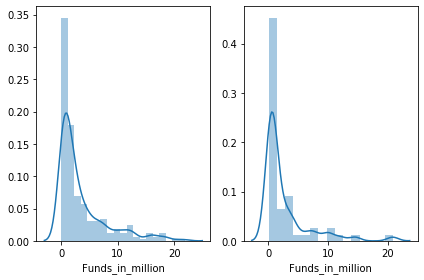

```python
#4A. Is there any significant difference between Funds raised by companies that are still operating vs companies that closed down?

from statsmodels.stats.weightstats import ztest
Operatingstartup=Startupdata[(Startupdata['OperatingState']=='Operating')]
Closedstartup=Startupdata[(Startupdata['OperatingState']=='Closed')]
fig, ax = plt.subplots(1,2)
sns.distplot(Operatingstartup['Funds_in_million'], ax=ax[0])
sns.distplot(Closedstartup['Funds_in_million'], ax=ax[1])
plt.tight_layout()
```

```python
#4B. Write the null hypothesis and alternative hypothesis.
NullHypothesis = "There is no significant difference between fund raised by Operating company and Closed Company"
AlternateHypothesis = "There is  significant difference between fund raised by Operating company and Closed Company"

print("Null Hypothesis H0 = ",NullHypothesis)
print("Alternate Hypothesis Ha = ",AlternateHypothesis)
```

```
Null Hypothesis H0 =  There is no significant difference between fund raised by Operating company and Closed Company
Alternate Hypothesis Ha =  There is  significant difference between fund raised by Operating company and Closed Company
```

```python
#4C. Test for significance and conclusion
tstatistic, pval = ztest(Operatingstartup['Funds_in_million'],Closedstartup['Funds_in_million'])

if pval < 0.05:
    print(f'With a p-value of {round(pval,4)} the difference is significant. |We reject the null|')
else:
    print(f'With a p-value of {round(pval,4)} the difference is not significant. |We fail to reject the null|')
```

```
With a p-value of 0.1923 the difference is not significant. |We fail to reject the null|
```

Conclusion : There is no significance difference between fund raised by Operating company and Closed Company

```python
#4D. Make a copy of the original data frame.
Startupdata_copy=Startupdata.copy(deep=True)
Startupdata_copy.head()
```

|  | Startup | Product | Funding | Event | Result | OperatingState | Funds_in_million |
| --- | --- | --- | --- | --- | --- | --- | --- |
| 1 | 3DLT | 3dlt.com | $630K | Disrupt NYC 2013 | Contestant | Closed | 0.63 |
| 3 | 3Dprintler | 3dprintler.com | $1M | Disrupt NY 2016 | Audience choice | Operating | 1.00 |
| 5 | 5to1 | 5to1.com | $19.3M | TC50 2009 | Contestant | Acquired | 19.30 |
| 10 | AdhereTech | adheretech.com | $1.8M | Hardware Battlefield 2014 | Contestant | Operating | 1.80 |
| 11 | AdRocket | adrocket.com | $1M | TC50 2008 | Contestant | Closed | 1.00 |

```
Contestant         282
Finalist            52
Audience choice     20
Winner              17
Runner up           15
Name: Result, dtype: int64
```

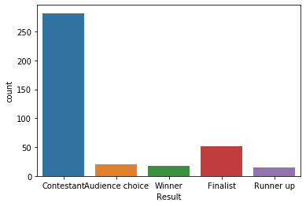

```python
#4E. Check frequency distribution of Result variables.
sns.countplot(x='Result',data=Startupdata)
Startupdata['Result'].value_counts()
```

Among 282 contestants , 17 Winners and 15 are Runner up

```python
Operatingstartup['Result'].value_counts()
```

```
Contestant         194
Finalist            37
Audience choice     18
Runner up           14
Winner              12
Name: Result, dtype: int64
```

```python
#4F. Calculate percentage of winners that are still operating and percentage of contestants that are still operating

Operatingstartup['Result'].value_counts()


OperatingWin=Startupdata['Result'][(Startupdata['OperatingState']=='Operating')].value_counts()['Winner']
totalwin=Startupdata['Result'].value_counts()['Winner']
print("percentage of winners that are still operating",OperatingWin/totalwin*100)

OperatingCont=Startupdata['Result'][(Startupdata['OperatingState']=='Operating')].value_counts()['Contestant']
totalCont=Startupdata['Result'].value_counts()['Contestant']
print("percentage of contestant that are still operating",OperatingCont/totalCont*100)
```

```
percentage of winners that are still operating 70.58823529411765
percentage of contestant that are still operating 68.79432624113475
```

```python
#4G. Write your hypothesis comparing the proportion of companies that are operating between winners and contestants:
NullHypothesis = "proportion of winners and contestants in operating companies are same "
AlternateHypothesis = "proportion of winners and contestants in operating companies are not same"

print("Null Hypothesis H0 = ",NullHypothesis)
print("Alternate Hypothesis Ha = ",AlternateHypothesis)
```

```
Null Hypothesis H0 =  proportion of winners and contestants in operating companies are same
Alternate Hypothesis Ha =  proportion of winners and contestants in operating companies are not same
```

```python
#4H. Test for significance and conclusion
from statsmodels.stats.proportion import proportions_ztest
stat, pval = proportions_ztest([OperatingWin,OperatingCont] , [totalwin,totalCont])

if pval < 0.05:
    print(f'With a p-value of {round(pval,4)} the difference is significant|We reject the null|')
else:
    print(f'With a p-value of {round(pval,4)} the difference is not significant |We fail to reject the null|')
```

```
With a p-value of 0.8767 the difference is not significant |We fail to reject the null|
```

Conclusion : there is no significant difference between the proportions of Winner and contestant in operating companies

```python
#4I. Select only the Event that has ‘disrupt’ keyword from 2013 onwards.
event=Startupdata.Event[(Startupdata['Event'].apply(lambda x:'Disrupt' in x and int(x[-4:])>=2013))]
```

```python
event
```

```
1         Disrupt NYC 2013
3          Disrupt NY 2016
13         Disrupt SF 2015
14     Disrupt London 2016
16         Disrupt SF 2015
18        Disrupt NYC 2014
42         Disrupt EU 2013
46         Disrupt SF 2015
51         Disrupt NY 2016
52         Disrupt SF 2014
53         Disrupt SF 2013
55         Disrupt NY 2016
59         Disrupt NY 2015
60         Disrupt NY 2016
63         Disrupt SF 2013
```

[output cut: 47 more lines]